# stage 2 - housing

Purva

2022-11-02

#### SID: 520434673

#### University of Sydney | MATH1005 | Lab Class 20 (Friday 12pm)

# IDA Source

- The data is sourced from the Australian Bureau of Statistics https://www.abs.gov.au/AUSSTATS/abs@.nsf/Latestproducts/1380.0.55.012Main%20Features12011 “Housing Arrangements” where the Australian Government aims to convey information about Housing Trends for the benefit of the general public.
- The dataset is valid because it is correctly formatted and stored. Although it is valid, it cannot be guaranteed that it is reliable. Since reliable data is defined as a trusted basis for analysis and decision - making. The accuracy of the data cannot be completely guaranteed. Despite coming from an extremely reputable source, changes in circumstances or data post-publication may affect the accuracy of the data.
- Possible issues may include inaccurate data due to changes in census after the data was collected. This is due to the rapid changing society and economy, as the there is a time gap between data collection and it being reported.
- Potential stakeholders include real estate agents who wish to understand the differences between dwellings in the different states and various LGAs of Australia. Additionally, it can also be helpful for the State and Local Government as it helps them idenitfy trends in housing, allowing them to use this information to create a provide an increased number of dwellings as required.

# IDA Variables

- The dataset consists of 14 column variables, each referring to different types of housing with the first column stating the LGA(s) and last column referring to the Australian states.
- The variables used in this report are Local Government Area, Owned - outright, Rented - Real estate agent, and State.
- These variables are the key defining information for each row of data collected. All the variables are of type character. The Owned - outright and Rented - real estate agent variables will be converted to numeric values for future calculations.
- The Local Government Area variable consists of area name keycodes ranging from - Cities (C), Areas (A), Rural Cities (RC), Boroughs (B), Shires (S), Towns (T), Regional Councils (R), Municipalities/Municipal Councils (M), District Councils (DC), Regional Councils (RegC), and Aboriginal Councils (AC). These keycodes help to provide specific information about the areas within each state.
- A snapshot of the data and variables is provided below.

```r
#read in data
data = read.csv("data/housing.csv")

#dimensions of the dataset
dim(data)
```

```
## [1] 559  14
```

```r
#show classification of variables
str(data)
```

```
## 'data.frame':    559 obs. of  14 variables:
##  $ Local.Government.Area                                   : chr  "LGA10050 Albury (C)" "LGA10110 Armidale Dumaresq (A)" "LGA10150 Ashfield (A)" "LGA10200 Auburn (C)" ...
##  $ Owned...outright                                        : chr  "5,440" "2,888" "4,408" "5,505" ...
##  $ Owned...with.a.mortgage                                 : chr  "6,403" "2,322" "4,240" "7,104" ...
##  $ Rented...Real.estate.agent                              : chr  "3,783" "1,803" "4,624" "5,824" ...
##  $ Rented...State.or.territory.housing.authority           : chr  "827" "451" "231" "836" ...
##  $ Rented...Person.not.in.same.household                   : chr  "1,067" "519" "972" "1,432" ...
##  $ Rented...Housing.co.operative..community.or.church.group: chr  "144" "103" "158" "130" ...
##  $ Rented...Other.landlord.type                            : chr  "170" "123" "93" "236" ...
##  $ Rented...Landlord.type.not.stated                       : chr  "88" "76" "62" "128" ...
##  $ Other.tenure.type                                       : chr  "149" "71" "125" "135" ...
##  $ Tenure.type.not.stated                                  : chr  "545" "233" "384" "751" ...
##  $ Total                                                   : chr  "18,616" "8,589" "15,297" "22,081" ...
##  $ Median.mortgage.repayment....monthly.                   : chr  "1,450" "1,430" "2,167" "2,000" ...
##  $ State                                                   : chr  "New South Wales" "New South Wales" "New South Wales" "New South Wales" ...
```

```r
typeof(data$Owned...outright)
```

```
## [1] "character"
```

```r
typeof(data$Owned...with.a.mortgage)
```

```
## [1] "character"
```

```r
typeof(data$State)
```

```
## [1] "character"
```

```r
typeof(data$Local.Government.Area)
```

```
## [1] "character"
```

# Question 1 - Does NSW have a higher number of properties owned(outright) as compared to Victoria?

I decided to compare the the properties owned in the top two populated states in Australia in 2011, which happen to be NSW and Victoria. (na, 2012)

### **Hypothesis**

If µ<sub>1</sub> is the average number of properties owned in NSW while µ<sub>2</sub> is the average properties owned in Victoria, we test $H0: µ1=µ2$ vs $H1:µ1>µ2$ using using α = 0.05 by convention.

### **Assumptions to perform a 2-sample t-test (assuming equal variance)**

- Both groups are independent of each other
- No significant outliers in either groups
- Assume that normal distribution is followed

```r
#Isolate data property owned data for NSW
#convert the numeric character to numeric values
nsw_owned= as.numeric(gsub(",", "", data$Owned...outright[data$State == "New South Wales"]))
nsw_owned
```

```
##   [1]  5440  2888  4408  5505  6274   327 19468  4472  5610  2236  1437 21763
##  [13]  1064   967 10489   427   502   483  3978   291   151  3347  3642  3923
##  [25]  2051  4648 11435  9267 14112   418   279  6344  8417   550  9284   231
##  [37]   688  1506   651  1351  1883  2006  1101  4223  1328  6635 18138  1338
##  [49]   708  1554   974 21597  3755  6783  1559  7707  2903   630  1701   712
##  [61]   973   694  6226   452  9577 19401  1758  9950  2331   252   721  4514
##  [73]  3316  7187 16373  1671  1068 27001  3961  1376  5205  5885  3132 12908
##  [85]  1269   542  7435  4882  7012  3387  1401  3945  1163   289  1511  3416
##  [97]  1757   918   936 18056  6927   793  4379  1831  2033 14250 15907  7831
## [109] 12184  9020  3600 13140  3233 11874 12134  7547 15584  2383   886  3256
## [121] 28286 10294  7375  1082  1260 19188   578  1668 13401  1849  1384   951
## [133]   222  6485   700   559  1019   464 16924  1749  6466   771  1256   917
## [145]  8355  6946  4298 25413  7211 18953  1799  1803
```

```r
#convert the numeric character to numeric values
vic_owned= as.numeric(gsub(",", "", data$Owned...outright[data$State == "Victoria"]))
vic_owned
```

```
##  [1]  2159  1973 11848 16998  5086  6259 14026  2288 23001 21436  1458  5383
## [13]  6602 19398  2448  3284  2796 17168  7631 12913  1993 17323  3176  2362
## [25] 13254 14851 29186  7142  2535  1254 11313  2938 15076  2281 19324 17837
## [37] 10017  1650  5335 18708  1262  6516 12966  6296  7657  6289  3558  4388
## [49] 24785 15342  3448 18997 20974  3230  2506  2266  7427  2139  8320  1406
## [61]   674  4591  3005 11869  1817  3419  2757  1069  4252  4220  6185   961
## [73] 22196 16547  3449 11423  6565 17312  1570
```

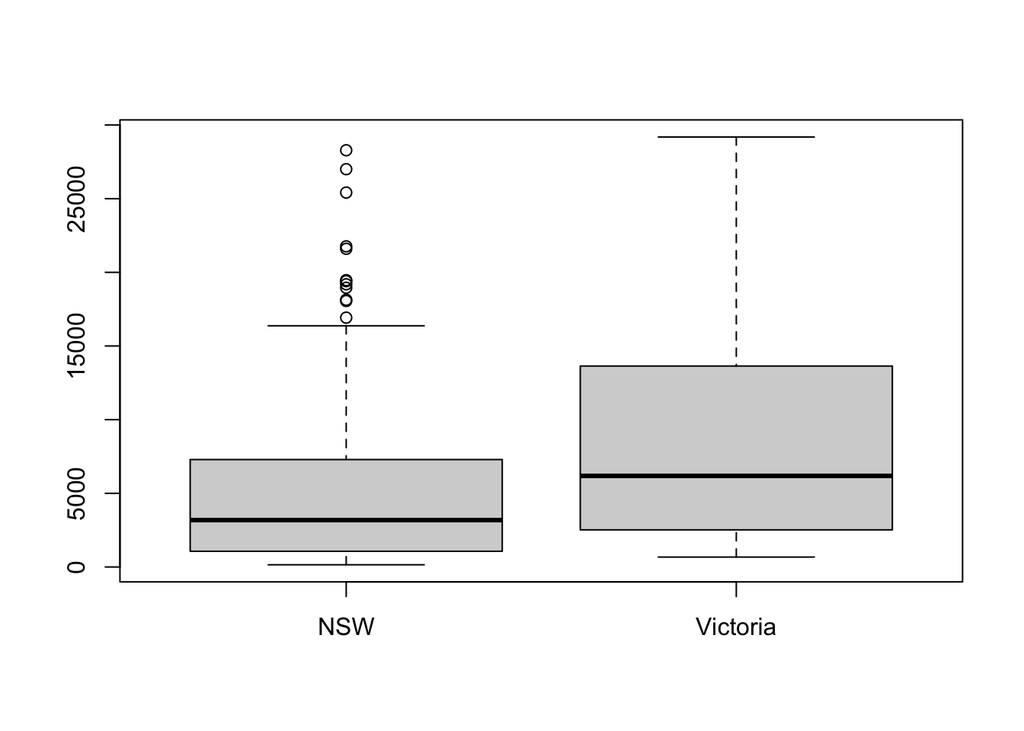

```r
#create a boxplot
boxplot(nsw_owned, vic_owned, names = c("NSW", "Victoria"))
```

### **Test-Statistics**

```r
#find the length of nsw and victoria vectors
n1 = length(nsw_owned)
n2 = length((vic_owned))

#find average
m1 = mean(nsw_owned)
m2 = mean(vic_owned)

#find variance
var1 = sd(nsw_owned) ^2
var2= sd(vic_owned)^2

#calculate t-test stat
sdp2 = ((n1 - 1) * var1 + (n2 - 1) * var2)/(n1 + n2 - 2)
se = sqrt(sdp2 * (1/n1 + 1/n2))
test = (m1 - m2 - 0)/se
test
```

```
## [1] -3.37322
```

#### **Using t.test() function**

```r
t.test(nsw_owned, vic_owned, alternative="greater")
```

```
##
##  Welch Two Sample t-test
##
## data:  nsw_owned and vic_owned
## t = -3.2104, df = 138.18, p-value = 0.9992
## alternative hypothesis: true difference in means is greater than 0
## 95 percent confidence interval:
##  -4590.966       Inf
## sample estimates:
## mean of x mean of y
##  5393.605  8422.316
```

### **p-value and conclusion**

```r
#calculate p-value
pval = pt(abs(test), n1+n2-2, lower.tail = T)
pval
```

```
## [1] 0.9995639
```

As the p-value is much greater than the significance level of 0.05, the null hypothesis can not be rejected, therefore it cannot be confirmed that NSW has a higher number of properties owned than Victoria. The larger p-value suggests that there is too much variability in the sample for the hypothesis test to detect an effect - which is possibly due to the greater number of outliers in the NSW sample data.

```r
sum(nsw_owned) > sum(vic_owned)
```

```
## [1] TRUE
```

This code suggests that the NSW data for homes owned outright is greater than Victorian homes owned outright.

### **Additional Research**

From the RBA report, Graph 14 shows that Victoria has a greater number of home ownerships than NSW. This contradicts the hypothesis made, suggesting that Victoria possible has greater number of homes owned as compared to NSW. (2015)

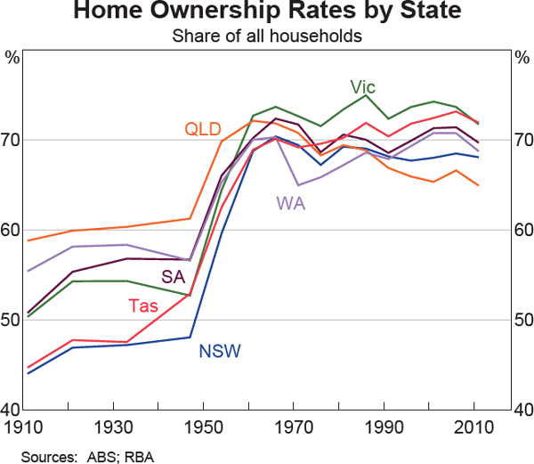

This is further supported by the following graph, which shows that over the years, NSW continues to have a lower number of homes owned despite the increase in population. (Hall, 2017)

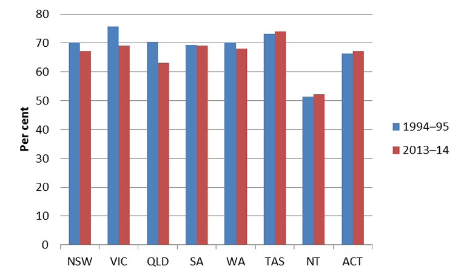

Sam Murden writes in the Real Estate news article that *“Increasing mortgage rates, combined with strong growth in home prices, have led to renting becoming an overall more affordable option across Australia now compared to this time last year”* (Murden, 2022), which presents a reason as to the why there is a declining trend in the number of homes owned in NSW and Victoria over the 20 years (depicted in the graph above).

Therefore, these sources act to provide information that denies the hypothesis made in Q1 - which is that NSW has a greater number of homes owned outright than Victoria.

The limitation of the additional research is that due to the rapidly changing society and economy, it is more difficult to find data and sources that provide information about housing trends from 2010.

# Question 2 - Does NSW have a higher number of properties rented (by real estate owner) than Victoria?

Continuing my comparison between NSW and Victoria, I decided to compare rental properties in the two states.

### **Hypothesis**

If µ<sub>1</sub> is the average homes rented in NSW while µ<sub>2</sub> is the average homes rented in Victoria, we test $H0: µ1=µ2$ vs $H1:µ1>µ2$ using using α = 0.05 by convention.

### **Assumptions to perform a 2-sample t-test (assuming equal variance)**

- Both groups are independent of each other
- No significant outliers in either groups
- Assume that normal distribution is followed

```r
#Isolate data property owned data for NSW
#convert the numeric character to numeric values
nsw_rent= as.numeric(gsub(",", "", data$Rented...Real.estate.agent[data$State == "New South Wales"]))
vic_rent= as.numeric(gsub(",", "", data$Rented...Real.estate.agent[data$State == "Victoria"]))

nsw_rent
```

```
##   [1]  3783  1803  4624  5824  2415    44  7236  2385  1462   572   314 14194
##  [13]   117   297  3338    58    32    60  2952    15     6   660  2702  1562
##  [25]   276  2112  6492  6539 10735    13     0  2727  2420   210  4513     6
##  [37]    39   448    68   238   495   561   449  2420   226  1839  8689   430
##  [49]   137   434   215  9688  1423  2164   200  2714  1419   102   622    77
##  [61]    90    78  2744    96  6919  6952   595  4995   790    22   196  1451
##  [73]   919  3685  3784   284   124  8044  2554   497  5902  2195   876  8351
##  [85]   261    30  3562  3894  9232  1153   618  2740   339    64  1099   948
##  [97]   380   162   242 10604 11000   220  2696   291   646 13245  9332  2193
## [109]  4401  3678  2399 13742  1151  7633  8521  2799  4540  1183   296  2913
## [121] 10089 28826  3339   166   221  5602    96   490  4939   527   120   168
## [133]     4  3732    89    57    77    27  8366   197  8226    74   334   201
## [145]  6292  1930  1231 10572  5597  9554   355   690
```

```r
vic_rent
```

```
##  [1]   465   402  6231  6088  1721  1621  4548   708 11575  7665    74  1522
## [13]  3372 10051   473   702   379 11842  1689  8354   351 11342   738   206
## [25]  5319  9164 11548  3100   407   141  5598  1087  5874   458  8418  5651
## [37]  3854    63  1038  4270   240  6380  5446 17690  4698  2940  1165  1082
## [49] 10165  7456   851 12725  6725   548   327   292  1060   423 16345    54
## [61]   122   797   472 12401   305  1112   877   130  1020  1967  1745    34
## [73]  8289  6674  2514  9737  9352  4117   151
```

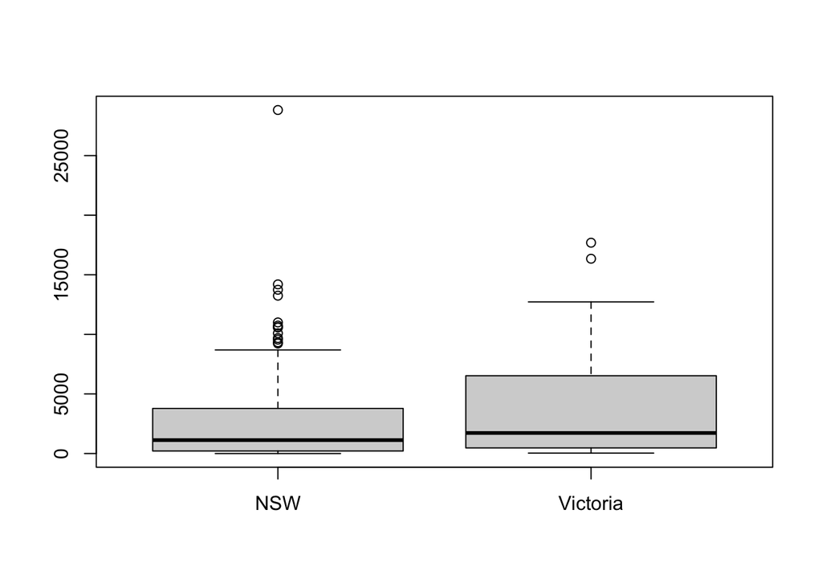

```r
#create boxplot
boxplot(nsw_rent, vic_rent, names = c("NSW", "Victoria"))
```

### **Test-Statistics**

```r
#find the length of nsw and victoria vectors
n1 = length(nsw_rent)
n2 = length((vic_rent))

#find average
m1 = mean(nsw_rent)
m2 = mean(vic_rent)

#find variance
var1 = sd(nsw_rent) ^2
var2= sd(vic_rent)^2

#calculate t-test stat
sdp2 = ((n1 - 1) * var1 + (n2 - 1) * var2)/(n1 + n2 - 2)
se = sqrt(sdp2 * (1/n1 + 1/n2))
test = (m1 - m2 - 0)/se
test
```

```
## [1] -2.062834
```

#### **Using t.test() function**

```r
t.test(nsw_rent, vic_rent, alternative="two.sided")
```

```
##
##  Welch Two Sample t-test
##
## data:  nsw_rent and vic_rent
## t = -2.0049, df = 146.19, p-value = 0.04682
## alternative hypothesis: true difference in means is not equal to 0
## 95 percent confidence interval:
##  -2337.18768   -16.76252
## sample estimates:
## mean of x mean of y
##  2829.822  4006.797
```

```r
sum(nsw_rent) > sum(vic_rent)
```

```
## [1] TRUE
```

### **Additional Research**

There is a trend with milennials renting more than buying, which is comes from the shift in lifestyles and more people being able to afford to rent than to buy homes. As Marisa states *“young people today renting more than ever before”* (Sanfilippo, 2022).

From the graph in the RBA report, we can visually notice the difference between the proportion of rental dwellings between the two states, with NSW having a higher proportion. (Evans et al., 2020)

[figure not shown]

[figure not shown]

# References

ABS (2022) *National, state and territory population, March 2022*, *Australian Bureau of Statistics*. Available at: https://www.abs.gov.au/statistics/people/population/national-state-and-territory-population/latest-release (Accessed: November 2, 2022).

Evans, R., Rosewall, T. and Wong, A. (2020) *The rental market and covid-19: Bulletin – September 2020*, *Reserve Bank of Australia*. Reserve Bank of Australia. Available at: https://www.rba.gov.au/publications/bulletin/2020/sep/the-rental-market-and-covid-19.html (Accessed: November 1, 2022).

geeksforgeeks (2021) *Sum of two or multiple DataFrame columns in R*, *GeeksforGeeks*. Available at: https://www.geeksforgeeks.org/sum-of-two-or-multiple-dataframe-columns-in-r/ (Accessed: October 31, 2022).

Government, A. (2021) *National, state and territory population, June 2021*, *National, state and territory population, June 2021 | Centre for Population*. Available at: https://population.gov.au/data-and-forecasts/key-data-releases/national-state-and-territory-population-june-2021 (Accessed: November 2, 2022).

Hall, A. (2017) *Trends in home ownership in Australia: A quick guide*, *Home – Parliament of Australia*. corporateName=Commonwealth Parliament; address=Parliament House, Canberra, ACT, 2600; contact=+61 2 6277 7111. Available at: https://www.aph.gov.au/About_Parliament/Parliamentary_Departments/Parliamentary_Library/pubs/rp/rp1617/Quick_Guides/TrendsHomeOwnership (Accessed: October 28, 2022).

*Home ownership rates: Submission to the inquiry into home ownership June 2015: Housing and Housing Finance: Submissions* (2015) *Reserve Bank of Australia*. Reserve Bank of Australia. Available at: https://www.rba.gov.au/publications/submissions/housing-and-housing-finance/inquiry-into-home-ownership/home-ownership-rates.html (Accessed: October 31, 2022).

Murden, S. (2022) *Buy don’t rent: NSW suburbs it’s cheaper to buy than rent according to PropTrack Buy or rent report*, *Search for Real Estate, Property & Homes*. Available at: https://www.realestate.com.au/news/buy-dont-rent-nsw-suburbs-its-cheaper-to-buy-than-rent-according-to-proptrack-buy-or-rent-report/ (Accessed: October 29, 2022).

na (2012) *Australian Demographic Statistics, Dec 2011*, *Australian Bureau of Statistics*. Available at: https://www.abs.gov.au/ausstats/abs@.nsf/7d12b0f6763c78caca257061001cc588/822f8c685f27dae1ca257a850013df78!OpenDocument (Accessed: November 2, 2022).

na (2020) *Main features - local government areas (lgas)*, *Australian Bureau of Statistics*. Available at: https://www.abs.gov.au/ausstats/abs@.nsf/Lookup/by%20Subject/1270.0.55.003~June%202020~Main%20Features~Local%20Government%20Areas%20(LGAs)~3 (Accessed: November 2, 2022).

Sanfilippo, M. (2022) *Why millennials are renting more - and why it works for them*, *MYMOVE*. Available at: https://www.mymove.com/moving/renters/why-millenials-rent-more/ (Accessed: November 2, 2022).